# Design of a credit scoring system for predicting loan default-LTFS HACKATHON ANALYTICS_VIDHYA

# Purpose of this code

This is an attempt to create a credit scoring system for predicting the probability of a borrower defaulting on vehilcle loan in First EMI on due dates. The data used for this modelling is obtained from “Analyticsvidhya LTFS Data challenge Hackathon” https://datahack.analyticsvidhya.com/contest/ltfs-datascience-finhack-an-online-hackathon/?utm_source=Sticky_banner1&utm_medium=display

```r
# setting the working directories
setwd("E:\\LTFS\\docs\\lasso")
```

```r
#~~~~~~~~~~~ Calling Libraries ~~~~~~~~~~~~~#

library(zoo)
library(dplyr)
library(tidyr)
library(stringi)
library(recommenderlab)
library(sqldf)
library(data.table)
library(ROCR)
library(caret)
library(ResourceSelection)
```

```
## ResourceSelection 0.3-2   2017-02-28
```

```r
library(stringr)
library(plotly)
library(knitr)
library(plotly)
library(eeptools)
library(Information)
library(stats)
library(rmarkdown)
library(magrittr)
library(randomForest)
```

Defining functions for various operations

```r
#Trim function for removing unwanted white spaces in data
trim <- function( x ) {
  gsub("(^[[:space:]]+|[[:space:]]+$)", "", x)
}

# A function to calculate percent distribution for factors
pct <- function(x){
  tbl <- table(x)
  tbl_pct <- cbind(tbl,round(prop.table(tbl)*100,2))
  colnames(tbl_pct) <- c('Count','Percentage')
  kable(tbl_pct)
}

# Function for  calculating WOE and Eefficiency
gbpct <- function(x, y=train$default_case){
  mt <- as.matrix(table(as.factor(x), as.factor(y)))
  Total <- mt[,1] + mt[,2]
  Total_Pct <- round(Total/sum(mt)*100, 2)
  Bad_pct <- round((mt[,1]/sum(mt[,1]))*100, 2)
  Good_pct <- round((mt[,2]/sum(mt[,2]))*100, 2)
  Bad_Rate <- round((mt[,1]/(mt[,1]+mt[,2]))*100, 2)
  grp_score <- round((Good_pct/(Good_pct + Bad_pct))*10, 2)
  WOE <- round(log(Good_pct/Bad_pct)*10, 2)
  g_b_comp <- ifelse(mt[,1] == mt[,2], 0, 1)
  IV <- ifelse(g_b_comp == 0, 0, (Good_pct - Bad_pct)*(WOE/10))
  Efficiency <- abs(Good_pct - Bad_pct)/2
  otb<-as.data.frame(cbind(mt, Good_pct,  Bad_pct,  Total,
                           Total_Pct,  Bad_Rate, grp_score,
                           WOE, IV, Efficiency ))
  otb$Names <- rownames(otb)
  rownames(otb) <- NULL
  otb[,c(12,2,1,3:11)]
}
```

```r
##Reading the data files for evaluation

#reading training data file
master_data<-read.csv("train.csv")
#reading data Data Dictionary
DataDictionary<-read.csv("Dictionary.csv")
```

```r
#Getting the variable names in data
train<-master_data #A copy of the master data for working
knitr::kable(as.data.frame(colnames(train)),format='markdown')
```

| colnames(train) |
| --- |
| UniqueID |
| disbursed_amount |
| asset_cost |
| ltv |
| branch_id |
| supplier_id |
| manufacturer_id |
| Current_pincode_ID |
| Date.of.Birth |
| Employment.Type |
| DisbursalDate |
| State_ID |
| Employee_code_ID |
| MobileNo_Avl_Flag |
| Aadhar_flag |
| PAN_flag |
| VoterID_flag |
| Driving_flag |
| Passport_flag |
| PERFORM_CNS.SCORE |
| PERFORM_CNS.SCORE.DESCRIPTION |
| PRI.NO.OF.ACCTS |
| PRI.ACTIVE.ACCTS |
| PRI.OVERDUE.ACCTS |
| PRI.CURRENT.BALANCE |
| PRI.SANCTIONED.AMOUNT |
| PRI.DISBURSED.AMOUNT |
| SEC.NO.OF.ACCTS |
| SEC.ACTIVE.ACCTS |
| SEC.OVERDUE.ACCTS |
| SEC.CURRENT.BALANCE |
| SEC.SANCTIONED.AMOUNT |
| SEC.DISBURSED.AMOUNT |
| PRIMARY.INSTAL.AMT |
| SEC.INSTAL.AMT |
| NEW.ACCTS.IN.LAST.SIX.MONTHS |
| DELINQUENT.ACCTS.IN.LAST.SIX.MONTHS |
| AVERAGE.ACCT.AGE |
| CREDIT.HISTORY.LENGTH |
| NO.OF_INQUIRIES |
| loan_default |

```r
summary(train)# getting summary of data
```

```
##     UniqueID      disbursed_amount   asset_cost           ltv
##  Min.   :417428   Min.   : 13320   Min.   :  37000   Min.   :10.03
##  1st Qu.:476786   1st Qu.: 47145   1st Qu.:  65717   1st Qu.:68.88
##  Median :535979   Median : 53803   Median :  70946   Median :76.80
##  Mean   :535918   Mean   : 54357   Mean   :  75865   Mean   :74.75
##  3rd Qu.:595040   3rd Qu.: 60413   3rd Qu.:  79202   3rd Qu.:83.67
##  Max.   :671084   Max.   :990572   Max.   :1628992   Max.   :95.00
##
##    branch_id       supplier_id    manufacturer_id  Current_pincode_ID
##  Min.   :  1.00   Min.   :10524   Min.   : 45.00   Min.   :   1
##  1st Qu.: 14.00   1st Qu.:16535   1st Qu.: 48.00   1st Qu.:1511
##  Median : 61.00   Median :20333   Median : 86.00   Median :2970
##  Mean   : 72.94   Mean   :19639   Mean   : 69.03   Mean   :3397
##  3rd Qu.:130.00   3rd Qu.:23000   3rd Qu.: 86.00   3rd Qu.:5677
##  Max.   :261.00   Max.   :24803   Max.   :156.00   Max.   :7345
##
##   Date.of.Birth         Employment.Type    DisbursalDate
##  01-01-88:  2173                :  7661   31-10-18:  8826
##  01-01-90:  2170   Salaried     : 97858   24-10-18:  6701
##  01-01-87:  2127   Self employed:127635   31-08-18:  6690
##  01-01-86:  2063                          23-10-18:  6440
##  01-01-85:  2005                          26-10-18:  6215
##  01-01-91:  1985                          25-10-18:  5944
##  (Other) :220631                          (Other) :192338
##     State_ID      Employee_code_ID MobileNo_Avl_Flag  Aadhar_flag
##  Min.   : 1.000   Min.   :   1     Min.   :1         Min.   :0.0000
##  1st Qu.: 4.000   1st Qu.: 713     1st Qu.:1         1st Qu.:1.0000
##  Median : 6.000   Median :1451     Median :1         Median :1.0000
##  Mean   : 7.262   Mean   :1549     Mean   :1         Mean   :0.8403
##  3rd Qu.:10.000   3rd Qu.:2362     3rd Qu.:1         3rd Qu.:1.0000
##  Max.   :22.000   Max.   :3795     Max.   :1         Max.   :1.0000
##
##     PAN_flag        VoterID_flag     Driving_flag     Passport_flag
##  Min.   :0.00000   Min.   :0.0000   Min.   :0.00000   Min.   :0.000000
##  1st Qu.:0.00000   1st Qu.:0.0000   1st Qu.:0.00000   1st Qu.:0.000000
##  Median :0.00000   Median :0.0000   Median :0.00000   Median :0.000000
##  Mean   :0.07558   Mean   :0.1449   Mean   :0.02324   Mean   :0.002127
##  3rd Qu.:0.00000   3rd Qu.:0.0000   3rd Qu.:0.00000   3rd Qu.:0.000000
##  Max.   :1.00000   Max.   :1.0000   Max.   :1.00000   Max.   :1.000000
##
```

[output cut: 49 more lines]

```
##  Min.   : 0.00000                    0yrs 0mon :119373
##  1st Qu.: 0.00000                    0yrs 6mon :  6028
##  Median : 0.00000                    0yrs 7mon :  5366
##  Mean   : 0.09748                    0yrs 11mon:  5237
##  3rd Qu.: 0.00000                    0yrs 10mon:  5143
##  Max.   :20.00000                    1yrs 0mon :  5031
##                                      (Other)   : 86976
##  CREDIT.HISTORY.LENGTH NO.OF_INQUIRIES    loan_default
##  0yrs 0mon:119127      Min.   : 0.0000   Min.   :0.0000
##  0yrs 6mon:  4761      1st Qu.: 0.0000   1st Qu.:0.0000
##  2yrs 1mon:  4745      Median : 0.0000   Median :0.0000
##  0yrs 7mon:  4017      Mean   : 0.2066   Mean   :0.2171
##  2yrs 0mon:  3833      3rd Qu.: 0.0000   3rd Qu.:0.0000
##  1yrs 0mon:  3389      Max.   :36.0000   Max.   :1.0000
##  (Other)  : 93282
```

CALCULATING AGE, TENURE etc in Months

```r
#finding total tenure in months

train<-train%>% separate( AVERAGE.ACCT.AGE,c("Age_Year","Age_Month")," ")
train$Loan_tenure_mon<-((as.numeric(gsub("yrs", "", train$Age_Year)))*12)+as.numeric(gsub("mon", "", train$Age_Month))
```

```r
#Credit history length in months
train<-train%>% separate( CREDIT.HISTORY.LENGTH ,c("CREDIT.HISTORY_Year","CREDIT.HISTORY_Month")," ")
train$Credit_history_mon<-((as.numeric(gsub("yrs", "", train$CREDIT.HISTORY_Year)))*12)+as.numeric(gsub("mon", "", train$CREDIT.HISTORY_Month))
```

```r
#analysing the loan default status in the data
train$default_case<-as.factor(ifelse(train$loan_default == 1, "Default", "Not_Default"))
pct(train$default_case)
```

|  | Count | Percentage |
| --- | --- | --- |
| Default | 50611 | 21.71 |
| Not_Default | 182543 | 78.29 |

[figure not shown]

```r
hist(as.numeric(train$default_case), breaks=2,
     xlab="Not_Default(1) and Default(2)", col="blue")
```

```r
#checking for the percentage of different type of applicants employment status
pct(train$Employment.Type)
```

[output not shown]

```r
#there are some missing values in the employment type column. We assume that those applicants are unemployed.
train$Employment.Type<-ifelse(train$Employment.Type == "","Unemployed",as.character(train$Employment.Type))
pct(train$Employment.Type)
```

[output not shown]

```r
train$Date.of.Birth<-as.Date(train$Date.of.Birth,"%d-%m-%y")
summary(train$Date.of.Birth)
```

```
##         Min.      1st Qu.       Median         Mean      3rd Qu.
## "1969-01-01" "1980-10-05" "1988-05-04" "1992-10-11" "1994-04-26"
##         Max.
## "2068-12-31"
```

Here the maximum value of date of birth is entered as “2068-12-31”. so we replace those dates with median(date of birth)

```r
median_dob<- median(train$Date.of.Birth)
median_dob
```

```
## [1] "1988-05-04"
```

```r
train$Date.of.Birth<-ifelse(train$Date.of.Birth> Sys.Date(),as.character(median_dob),as.character(train$Date.of.Birth))
train$Date.of.Birth<-as.Date(train$Date.of.Birth,"%Y-%m-%d")
train<-filter(train,Date.of.Birth < Sys.Date())
```

# Binning Data for Analysis

Create as many as subgroups for independent variables and calculate Weight of Evidence (WOE) and Information Value(IV) of the variable based on WOE’s and IV’s of subgroups respectively.

# Analysing loan tenure, grouping the loan tenure to bins , calculation of WOE and IV .

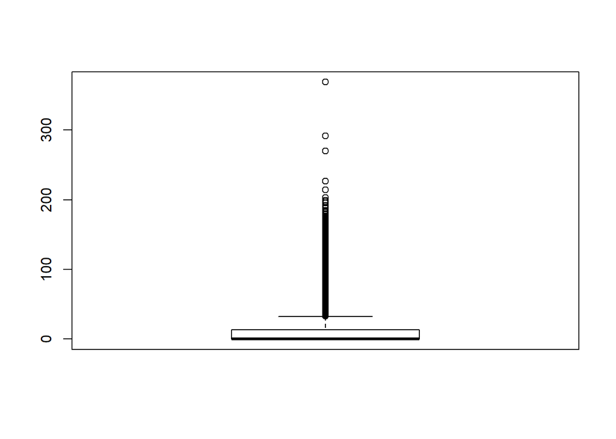

```r
boxplot(as.numeric(train$Loan_tenure_mon))
```

```r
summary(train$Loan_tenure_mon)
```

```
##    Min. 1st Qu.  Median    Mean 3rd Qu.    Max.
##   0.000   0.000   0.000   8.916  13.000 369.000
```

```r
pct(train$Loan_tenure_mon)
```

|  | Count | Percentage |
| --- | --- | --- |
| 0 | 119373 | 51.20 |
| 1 | 2207 | 0.95 |
| 2 | 2933 | 1.26 |
| 3 | 3570 | 1.53 |
| 4 | 4269 | 1.83 |
| 5 | 4354 | 1.87 |
| 6 | 6028 | 2.59 |
| 7 | 5366 | 2.30 |
| 8 | 4892 | 2.10 |
| 9 | 5018 | 2.15 |
| 10 | 5143 | 2.21 |
| 11 | 5237 | 2.25 |
| 12 | 5031 | 2.16 |
| 13 | 4465 | 1.92 |
| 14 | 3941 | 1.69 |
| 15 | 3694 | 1.58 |
| 16 | 3146 | 1.35 |
| 17 | 2980 | 1.28 |
| 18 | 2782 | 1.19 |
| 19 | 2477 | 1.06 |
| 20 | 2216 | 0.95 |
| 21 | 2037 | 0.87 |
| 22 | 1978 | 0.85 |
| 23 | 1903 | 0.82 |
| 24 | 1963 | 0.84 |
| 25 | 1945 | 0.83 |
| 26 | 1478 | 0.63 |
| 27 | 1270 | 0.54 |
| 28 | 1241 | 0.53 |
| 29 | 1128 | 0.48 |

[output cut: 162 more lines]

```r
train$Loan_tenure_grp <-as.factor(ifelse(train$Loan_tenure_mon<=6,'00-06',
                                         ifelse(train$Loan_tenure_mon<=12,'06-12',
                                                ifelse(train$Loan_tenure_mon<=24,'12-24',
                                                       ifelse(train$Loan_tenure_mon<=30,'24-30',
                                                              ifelse(train$Loan_tenure_mon<=36,'30-36',
                                                                     ifelse(train$Loan_tenure_mon<=42,'36-42','42+')))))))

pct(train$Loan_tenure_grp)
```

|  | Count | Percentage |
| --- | --- | --- |
| 00-06 | 142734 | 61.22 |
| 06-12 | 30687 | 13.16 |
| 12-24 | 33582 | 14.40 |
| 24-30 | 8227 | 3.53 |
| 30-36 | 5484 | 2.35 |
| 36-42 | 3667 | 1.57 |
| 42+ | 8773 | 3.76 |

```r
WOE_credit_tenure<-gbpct(train$Loan_tenure_grp)
kable(WOE_credit_tenure, caption = 'Loan Duration ~ Not Default-Default')
```

Loan Duration ~ Not Default-Default

| Names | Not_Default | Default | Good_pct | Bad_pct | Total | Total_Pct | Bad_Rate | grp_score | WOE | IV | Efficiency |
| --- | --- | --- | --- | --- | --- | --- | --- | --- | --- | --- | --- |
| 00-06 | 110193 | 32541 | 60.37 | 64.30 | 142734 | 61.22 | 22.80 | 4.84 | -0.63 | 0.24759 | 1.965 |
| 06-12 | 24650 | 6037 | 13.50 | 11.93 | 30687 | 13.16 | 19.67 | 5.31 | 1.24 | 0.19468 | 0.785 |
| 12-24 | 26811 | 6771 | 14.69 | 13.38 | 33582 | 14.40 | 20.16 | 5.23 | 0.93 | 0.12183 | 0.655 |
| 24-30 | 6599 | 1628 | 3.62 | 3.22 | 8227 | 3.53 | 19.79 | 5.29 | 1.17 | 0.04680 | 0.200 |
| 30-36 | 4322 | 1162 | 2.37 | 2.30 | 5484 | 2.35 | 21.19 | 5.07 | 0.30 | 0.00210 | 0.035 |
| 36-42 | 2886 | 781 | 1.58 | 1.54 | 3667 | 1.57 | 21.30 | 5.06 | 0.26 | 0.00104 | 0.020 |
| 42+ | 7082 | 1691 | 3.88 | 3.34 | 8773 | 3.76 | 19.28 | 5.37 | 1.50 | 0.08100 | 0.270 |

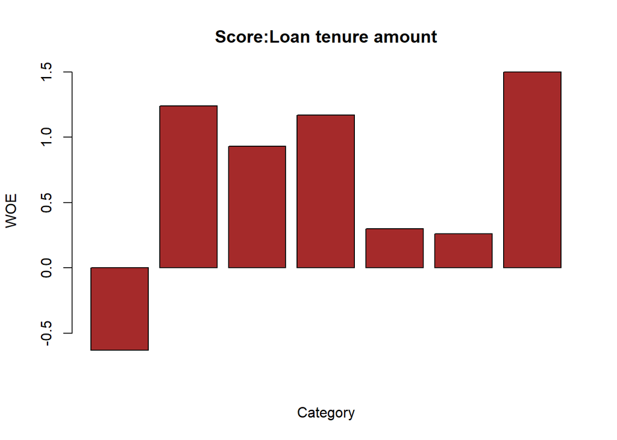

```r
barplot(WOE_credit_tenure$WOE, col="brown", names.arg=c(WOE_credit_tenure$Levels),
        main="Score:Loan tenure amount",
        xlab="Category",
        ylab="WOE")
```

# Analysing Disbursed loan amount , calculation of WOE and IV .

```r
train$disbursed_amount<-as.numeric(train$disbursed_amount)
summary(train$disbursed_amount)
```

```
##    Min. 1st Qu.  Median    Mean 3rd Qu.    Max.
##   13320   47145   53803   54357   60413  990572
```

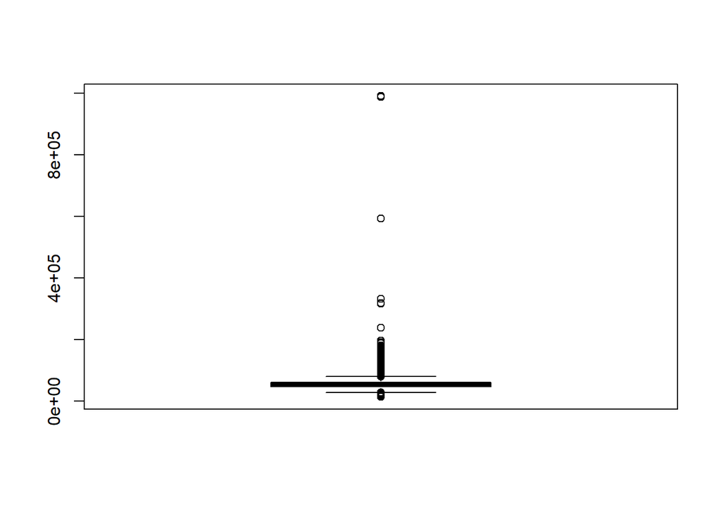

```r
boxplot(train$disbursed_amount)
```

```r
train$disbursed_amount_grp<-as.factor(ifelse(train$disbursed_amount<=20000,'0-20000',
                                             ifelse(train$disbursed_amount<=35000,'20000-35000',
                                                    ifelse(train$disbursed_amount<=50000,'35000-50000',
                                                           ifelse(train$disbursed_amount<=75000,'50000-75000',
                                                                  ifelse(train$disbursed_amount<=100000,'75000-100000','100000 above'))))))


pct(train$disbursed_amount_grp)
```

|  | Count | Percentage |
| --- | --- | --- |
| 0-20000 | 441 | 0.19 |
| 100000 above | 835 | 0.36 |
| 20000-35000 | 11428 | 4.90 |
| 35000-50000 | 68950 | 29.57 |
| 50000-75000 | 141400 | 60.65 |
| 75000-100000 | 10100 | 4.33 |

```r
WOE_Disbursed_Amt<-gbpct(train$disbursed_amount_grp)
kable(WOE_Disbursed_Amt, caption = 'Loan Disbursed ~ Not Default-Default')
```

Loan Disbursed ~ Not Default-Default

| Names | Not_Default | Default | Good_pct | Bad_pct | Total | Total_Pct | Bad_Rate | grp_score | WOE | IV | Efficiency |
| --- | --- | --- | --- | --- | --- | --- | --- | --- | --- | --- | --- |
| 0-20000 | 369 | 72 | 0.20 | 0.14 | 441 | 0.19 | 16.33 | 5.88 | 3.57 | 0.02142 | 0.030 |
| 100000 above | 660 | 175 | 0.36 | 0.35 | 835 | 0.36 | 20.96 | 5.07 | 0.28 | 0.00028 | 0.005 |
| 20000-35000 | 9847 | 1581 | 5.39 | 3.12 | 11428 | 4.90 | 13.83 | 6.33 | 5.47 | 1.24169 | 1.135 |
| 35000-50000 | 56993 | 11957 | 31.22 | 23.63 | 68950 | 29.57 | 17.34 | 5.69 | 2.79 | 2.11761 | 3.795 |
| 50000-75000 | 107207 | 34193 | 58.73 | 67.56 | 141400 | 60.65 | 24.18 | 4.65 | -1.40 | 1.23620 | 4.415 |
| 75000-100000 | 7467 | 2633 | 4.09 | 5.20 | 10100 | 4.33 | 26.07 | 4.40 | -2.40 | 0.26640 | 0.555 |

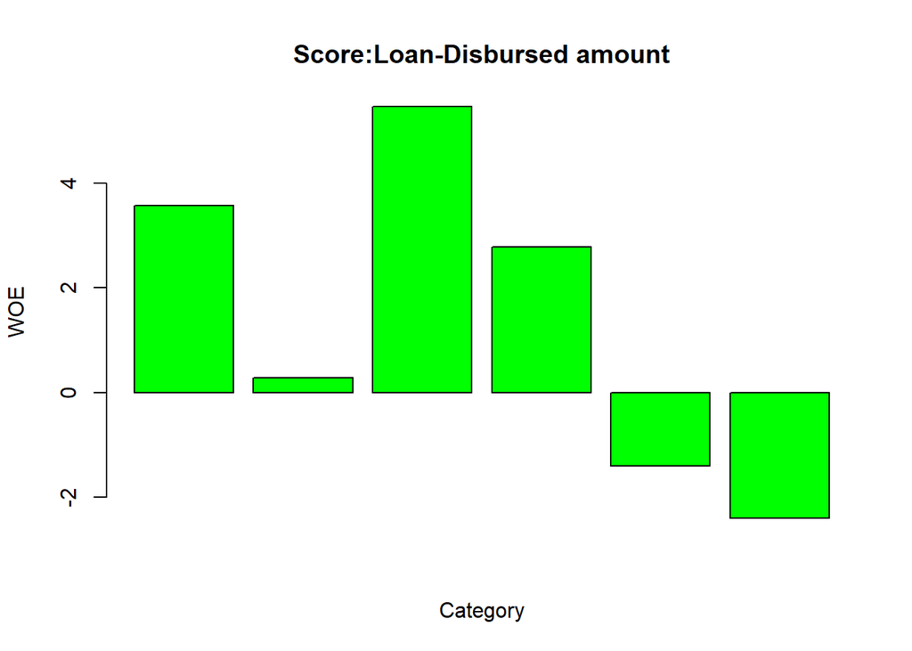

```r
barplot(WOE_Disbursed_Amt$WOE, col="green", names.arg=c(WOE_Disbursed_Amt$Levels),
        main="Score:Loan-Disbursed amount",
        xlab="Category",
        ylab="WOE")
```

# Analysing Credit Score and calculating WOE and IV

Higher the credit score lower the risk

```r
summary(train$PERFORM_CNS.SCORE)
```

```
##    Min. 1st Qu.  Median    Mean 3rd Qu.    Max.
##     0.0     0.0     0.0   289.5   678.0   890.0
```

```r
train$PERFORM_CNS.SCORE_grp<-as.factor(ifelse(train$PERFORM_CNS.SCORE<=250,'0-250',
                                              ifelse(train$PERFORM_CNS.SCORE<=500,'250-500',
                                                     ifelse(train$PERFORM_CNS.SCORE<=750,'500-750',
                                                            ifelse(train$PERFORM_CNS.SCORE<=1000,'750-1000','1000 above')))))

pct(train$PERFORM_CNS.SCORE_grp)
```

|  | Count | Percentage |
| --- | --- | --- |
| 0-250 | 129785 | 55.66 |
| 250-500 | 17188 | 7.37 |
| 500-750 | 60499 | 25.95 |
| 750-1000 | 25682 | 11.02 |

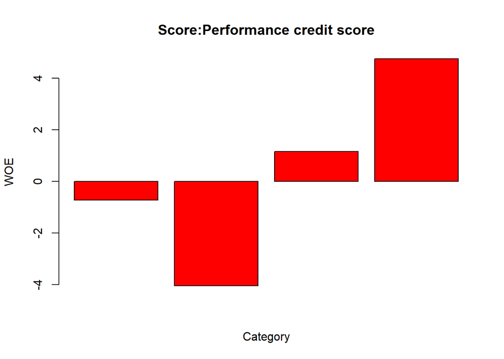

```r
WOE_CNS_Score_grp<-gbpct(train$PERFORM_CNS.SCORE_grp)
barplot(WOE_CNS_Score_grp$WOE, col="red", names.arg=c(WOE_CNS_Score_grp$Levels),
        main="Score:Performance credit score",
        xlab="Category",
        ylab="WOE")
```

```r
kable(WOE_CNS_Score_grp, caption = 'Bureau Score ~ Not Default-Default')
```

Bureau Score ~ Not Default-Default

| Names | Not_Default | Default | Good_pct | Bad_pct | Total | Total_Pct | Bad_Rate | grp_score | WOE | IV | Efficiency |
| --- | --- | --- | --- | --- | --- | --- | --- | --- | --- | --- | --- |
| 0-250 | 99970 | 29815 | 54.77 | 58.91 | 129785 | 55.66 | 22.97 | 4.82 | -0.73 | 0.30222 | 2.070 |
| 250-500 | 12148 | 5040 | 6.65 | 9.96 | 17188 | 7.37 | 29.32 | 4.00 | -4.04 | 1.33724 | 1.655 |
| 500-750 | 48517 | 11982 | 26.58 | 23.67 | 60499 | 25.95 | 19.81 | 5.29 | 1.16 | 0.33756 | 1.455 |
| 750-1000 | 21908 | 3774 | 12.00 | 7.46 | 25682 | 11.02 | 14.70 | 6.17 | 4.75 | 2.15650 | 2.270 |

# Analysing Asset cost and calculation of WOE and IV

```r
summary(train$asset_cost)
```

```
##    Min. 1st Qu.  Median    Mean 3rd Qu.    Max.
##   37000   65717   70946   75865   79202 1628992
```

```r
train$asset_cost_grp<-as.factor(ifelse(train$asset_cost<=50000,'0-50000',
                                       ifelse(train$asset_cost<=75000,'50000-75000',
                                              ifelse(train$asset_cost<=100000,'75000-100000',
                                                     ifelse(train$asset_cost<=150000,'100000-150000','150000 above')))))
pct(train$asset_cost_grp)
```

|  | Count | Percentage |
| --- | --- | --- |
| 0-50000 | 3483 | 1.49 |
| 100000-150000 | 19193 | 8.23 |
| 150000 above | 2812 | 1.21 |
| 50000-75000 | 148161 | 63.55 |
| 75000-100000 | 59505 | 25.52 |

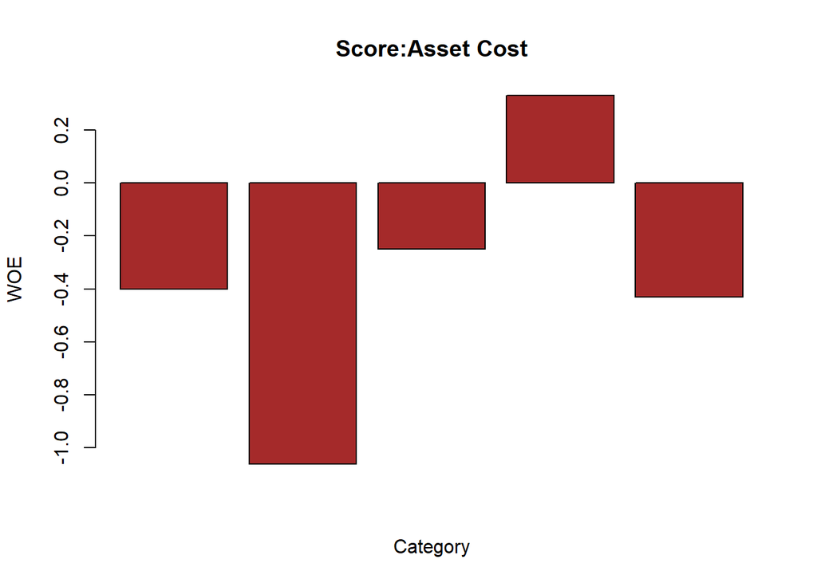

```r
WOE_asset_cost_grp<-gbpct(train$asset_cost_grp)
barplot(WOE_asset_cost_grp$WOE, col="brown", names.arg=c(WOE_asset_cost_grp$Levels),
        main="Score:Asset Cost",
        xlab="Category",
        ylab="WOE")
```

```r
kable(WOE_asset_cost_grp, caption = 'Asset Cost ~ Not Default-Default')
```

Asset Cost ~ Not Default-Default

| Names | Not_Default | Default | Good_pct | Bad_pct | Total | Total_Pct | Bad_Rate | grp_score | WOE | IV | Efficiency |
| --- | --- | --- | --- | --- | --- | --- | --- | --- | --- | --- | --- |
| 0-50000 | 2702 | 781 | 1.48 | 1.54 | 3483 | 1.49 | 22.42 | 4.90 | -0.40 | 0.00240 | 0.030 |
| 100000-150000 | 14669 | 4524 | 8.04 | 8.94 | 19193 | 8.23 | 23.57 | 4.73 | -1.06 | 0.09540 | 0.450 |
| 150000 above | 2191 | 621 | 1.20 | 1.23 | 2812 | 1.21 | 22.08 | 4.94 | -0.25 | 0.00075 | 0.015 |
| 50000-75000 | 116830 | 31331 | 64.00 | 61.91 | 148161 | 63.55 | 21.15 | 5.08 | 0.33 | 0.06897 | 1.045 |
| 75000-100000 | 46151 | 13354 | 25.28 | 26.39 | 59505 | 25.52 | 22.44 | 4.89 | -0.43 | 0.04773 | 0.555 |

# Analysing Credit history length and calculation of WOE and IV

```r
summary(train$Credit_history_mon)
```

```
##    Min. 1st Qu.  Median    Mean 3rd Qu.    Max.
##    0.00    0.00    0.00   16.25   24.00  468.00
```

```r
train$Credit_history_grp <-as.factor(ifelse(train$Credit_history_mon<=6,'00-06',
                                            ifelse(train$Credit_history_mon<=12,'06-12',
                                                   ifelse(train$Credit_history_mon<=24,'12-24',
                                                          ifelse(train$Credit_history_mon<=30,'24-30',
                                                                 ifelse(train$Credit_history_mon<=36,'30-36',
                                                                        ifelse(train$Credit_history_mon<=42,'36-42','42+')))))))
pct(train$Credit_history_grp)
```

|  | Count | Percentage |
| --- | --- | --- |
| 00-06 | 133929 | 57.44 |
| 06-12 | 17262 | 7.40 |
| 12-24 | 27057 | 11.60 |
| 24-30 | 12206 | 5.24 |
| 30-36 | 8256 | 3.54 |
| 36-42 | 6331 | 2.72 |
| 42+ | 28113 | 12.06 |

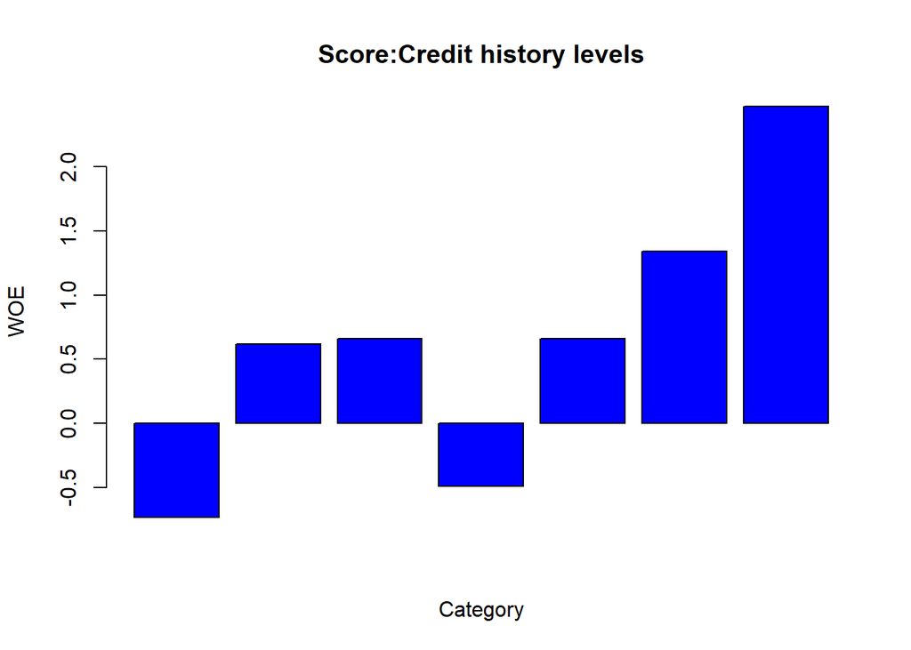

```r
WOE_Credit_history_grp<-gbpct(train$Credit_history_grp)
barplot(WOE_Credit_history_grp$WOE, col="blue", names.arg=c(WOE_Credit_history_grp$Levels),
        main="Score:Credit history levels",
        xlab="Category",
        ylab="WOE")
```

```r
kable(WOE_Credit_history_grp, caption = 'Credit history ~ Not Default-Default')
```

Credit history ~ Not Default-Default

| Names | Not_Default | Default | Good_pct | Bad_pct | Total | Total_Pct | Bad_Rate | grp_score | WOE | IV | Efficiency |
| --- | --- | --- | --- | --- | --- | --- | --- | --- | --- | --- | --- |
| 00-06 | 103151 | 30778 | 56.51 | 60.81 | 133929 | 57.44 | 22.98 | 4.82 | -0.73 | 0.31390 | 2.150 |
| 06-12 | 13696 | 3566 | 7.50 | 7.05 | 17262 | 7.40 | 20.66 | 5.15 | 0.62 | 0.02790 | 0.225 |
| 12-24 | 21481 | 5576 | 11.77 | 11.02 | 27057 | 11.60 | 20.61 | 5.16 | 0.66 | 0.04950 | 0.375 |
| 24-30 | 9455 | 2751 | 5.18 | 5.44 | 12206 | 5.24 | 22.54 | 4.88 | -0.49 | 0.01274 | 0.130 |
| 30-36 | 6557 | 1699 | 3.59 | 3.36 | 8256 | 3.54 | 20.58 | 5.17 | 0.66 | 0.01518 | 0.115 |
| 36-42 | 5094 | 1237 | 2.79 | 2.44 | 6331 | 2.72 | 19.54 | 5.33 | 1.34 | 0.04690 | 0.175 |
| 42+ | 23109 | 5004 | 12.66 | 9.89 | 28113 | 12.06 | 17.80 | 5.61 | 2.47 | 0.68419 | 1.385 |

# Analysing LTV - WOE and IV calculation

```r
train$ltv<-(train$ltv)/100
summary(train$ltv)
```

```
##    Min. 1st Qu.  Median    Mean 3rd Qu.    Max.
##  0.1003  0.6888  0.7680  0.7475  0.8367  0.9500
```

```r
train$ltv_grp<-as.factor(ifelse(train$ltv<=0.25,'0-25%',
                                ifelse(train$ltv<=0.50,'25%-50%',
                                       ifelse(train$ltv<=0.75,'50%-75%','75%-100%'))))
pct(train$ltv_grp)
```

|  | Count | Percentage |
| --- | --- | --- |
| 0-25% | 177 | 0.08 |
| 25%-50% | 8814 | 3.78 |
| 50%-75% | 96901 | 41.56 |
| 75%-100% | 127262 | 54.58 |

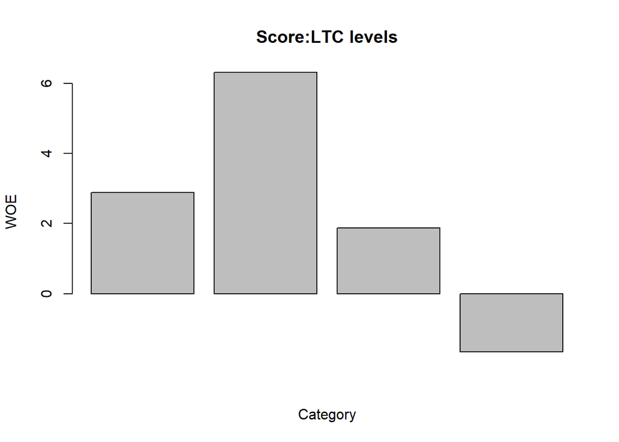

```r
WOE_ltv_grp<-gbpct(train$ltv_grp)
barplot(WOE_ltv_grp$WOE, col="grey", names.arg=c(WOE_ltv_grp$Levels),
        main="Score:LTC levels",
        xlab="Category",
        ylab="WOE")
```

```r
kable(WOE_ltv_grp, caption = 'LTV ~ Not Default-Default')
```

LTV ~ Not Default-Default

| Names | Not_Default | Default | Good_pct | Bad_pct | Total | Total_Pct | Bad_Rate | grp_score | WOE | IV | Efficiency |
| --- | --- | --- | --- | --- | --- | --- | --- | --- | --- | --- | --- |
| 0-25% | 147 | 30 | 0.08 | 0.06 | 177 | 0.08 | 16.95 | 5.71 | 2.88 | 0.00576 | 0.010 |
| 25%-50% | 7680 | 1134 | 4.21 | 2.24 | 8814 | 3.78 | 12.87 | 6.53 | 6.31 | 1.24307 | 0.985 |
| 50%-75% | 78800 | 18101 | 43.17 | 35.76 | 96901 | 41.56 | 18.68 | 5.47 | 1.88 | 1.39308 | 3.705 |
| 75%-100% | 95916 | 31346 | 52.54 | 61.94 | 127262 | 54.58 | 24.63 | 4.59 | -1.65 | 1.55100 | 4.700 |

# Analysing Employment type WOE and IV calculation

```r
unique(train$Employment.Type)
```

```
## [1] "Salaried"      "Self employed" "Unemployed"
```

```r
pct(train$Employment.Type)
```

|  | Count | Percentage |
| --- | --- | --- |
| Salaried | 97858 | 41.97 |
| Self employed | 127635 | 54.74 |
| Unemployed | 7661 | 3.29 |

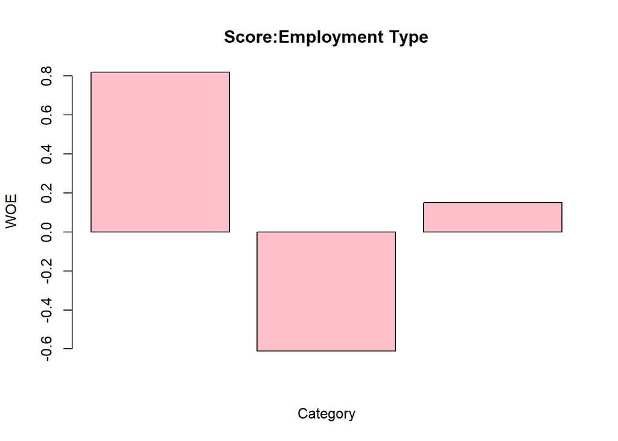

```r
WOE_Employment_Type<-gbpct(train$Employment.Type)
barplot(WOE_Employment_Type$WOE, col="pink", names.arg=c(WOE_Employment_Type$Levels),
        main="Score:Employment Type",
        xlab="Category",
        ylab="WOE")
```

```r
kable(WOE_Employment_Type, caption = 'Employment Type ~ Not Default-Default')
```

Employment Type ~ Not Default-Default

| Names | Not_Default | Default | Good_pct | Bad_pct | Total | Total_Pct | Bad_Rate | grp_score | WOE | IV | Efficiency |
| --- | --- | --- | --- | --- | --- | --- | --- | --- | --- | --- | --- |
| Salaried | 77948 | 19910 | 42.7 | 39.34 | 97858 | 41.97 | 20.35 | 5.20 | 0.82 | 0.27552 | 1.680 |
| Self employed | 98578 | 29057 | 54.0 | 57.41 | 127635 | 54.74 | 22.77 | 4.85 | -0.61 | 0.20801 | 1.705 |
| Unemployed | 6017 | 1644 | 3.3 | 3.25 | 7661 | 3.29 | 21.46 | 5.04 | 0.15 | 0.00075 | 0.025 |

# Analysing new accounts in 6 months-WOE and IV calculation

```r
summary(train$NEW.ACCTS.IN.LAST.SIX.MONTHS)
```

```
##    Min. 1st Qu.  Median    Mean 3rd Qu.    Max.
##  0.0000  0.0000  0.0000  0.3818  0.0000 35.0000
```

```r
train$new_acc_grp<-as.factor(ifelse(train$NEW.ACCTS.IN.LAST.SIX.MONTHS<=1,'0-1',
                                    ifelse(train$NEW.ACCTS.IN.LAST.SIX.MONTHS<=3,'1-3','3+')))
WOE_new_acc<-gbpct(train$new_acc_grp)
pct(train$new_acc_grp)
```

|  | Count | Percentage |
| --- | --- | --- |
| 0-1 | 213593 | 91.61 |
| 1-3 | 15473 | 6.64 |
| 3+ | 4088 | 1.75 |

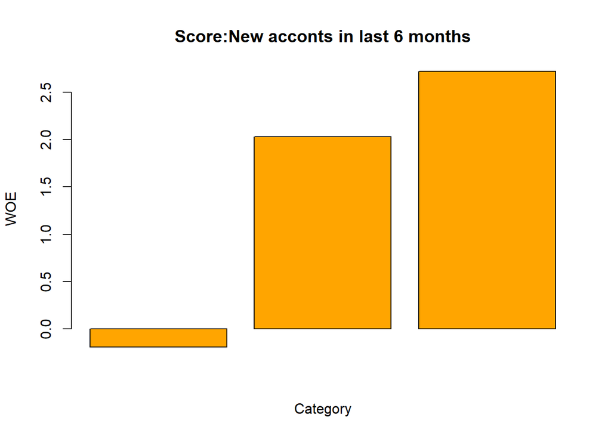

```r
barplot(WOE_new_acc$WOE, col="orange", names.arg=c(WOE_new_acc$Levels),
        main="Score:New acconts in last 6 months",
        xlab="Category",
        ylab="WOE")
```

```r
kable(WOE_new_acc, caption = 'New Accounts in 6 months ~ Not Default-Default')
```

New Accounts in 6 months ~ Not Default-Default

| Names | Not_Default | Default | Good_pct | Bad_pct | Total | Total_Pct | Bad_Rate | grp_score | WOE | IV | Efficiency |
| --- | --- | --- | --- | --- | --- | --- | --- | --- | --- | --- | --- |
| 0-1 | 166547 | 47046 | 91.24 | 92.96 | 213593 | 91.61 | 22.03 | 4.95 | -0.19 | 0.03268 | 0.860 |
| 1-3 | 12621 | 2852 | 6.91 | 5.64 | 15473 | 6.64 | 18.43 | 5.51 | 2.03 | 0.25781 | 0.635 |
| 3+ | 3375 | 713 | 1.85 | 1.41 | 4088 | 1.75 | 17.44 | 5.67 | 2.72 | 0.11968 | 0.220 |

# Analysing delinquent accounts in Past 6 months WOE and IV Calculation

```r
summary(train$DELINQUENT.ACCTS.IN.LAST.SIX.MONTHS)
```

```
##     Min.  1st Qu.   Median     Mean  3rd Qu.     Max.
##  0.00000  0.00000  0.00000  0.09748  0.00000 20.00000
```

```r
train$deliq_acc_grp<-as.factor(ifelse(train$DELINQUENT.ACCTS.IN.LAST.SIX.MONTHS<=1,'0-1',
                                      ifelse(train$DELINQUENT.ACCTS.IN.LAST.SIX.MONTHS<=3,'1-3','3+')))
pct(train$deliq_acc_grp)
```

|  | Count | Percentage |
| --- | --- | --- |
| 0-1 | 229900 | 98.60 |
| 1-3 | 3007 | 1.29 |
| 3+ | 247 | 0.11 |

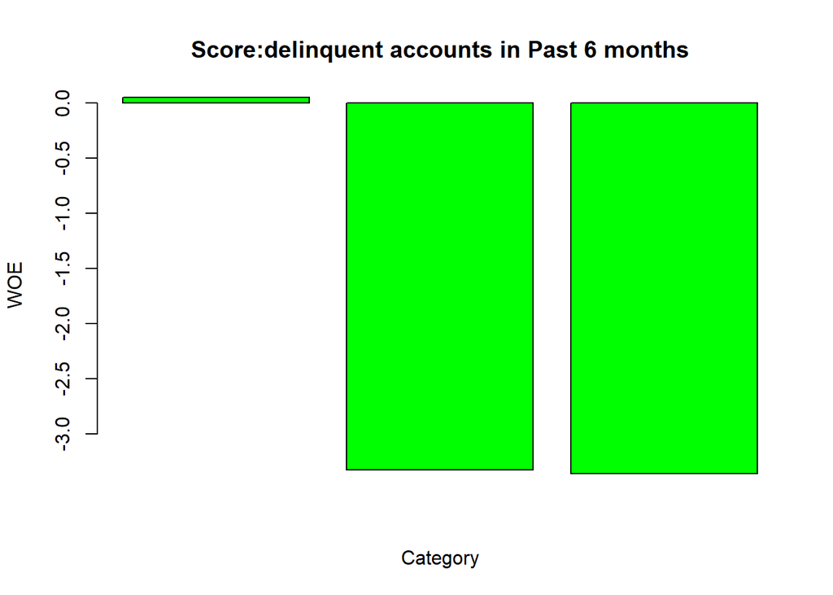

```r
WOE_deliq_acc<-gbpct(train$deliq_acc_grp)
barplot(WOE_deliq_acc$WOE, col="green", names.arg=c(WOE_deliq_acc$Levels),
        main="Score:delinquent accounts in Past 6 months",
        xlab="Category",
        ylab="WOE")
```

```r
kable(WOE_deliq_acc, caption = 'Delinquent accounts in 6 months ~ Not Default-Default')
```

Delinquent accounts in 6 months ~ Not Default-Default

| Names | Not_Default | Default | Good_pct | Bad_pct | Total | Total_Pct | Bad_Rate | grp_score | WOE | IV | Efficiency |
| --- | --- | --- | --- | --- | --- | --- | --- | --- | --- | --- | --- |
| 0-1 | 180199 | 49701 | 98.72 | 98.20 | 229900 | 98.60 | 21.62 | 5.01 | 0.05 | 0.00260 | 0.260 |
| 1-3 | 2169 | 838 | 1.19 | 1.66 | 3007 | 1.29 | 27.87 | 4.18 | -3.33 | 0.15651 | 0.235 |
| 3+ | 175 | 72 | 0.10 | 0.14 | 247 | 0.11 | 29.15 | 4.17 | -3.36 | 0.01344 | 0.020 |

# Analysing age of clients ;WOE & IV calculation

```r
train$Applicant_Age<-round(age_calc(as.Date(train$Date.of.Birth,"%d-%m-%y"), units = "years",precise = T))
summary(train$Applicant_Age)
```

```
##    Min. 1st Qu.  Median    Mean 3rd Qu.    Max.
##   19.00   27.00   31.00   33.43   39.00   51.00
```

```r
train$Applicant_Age_grp <-as.factor(ifelse(train$Applicant_Age<=25,'0-25',
                                           ifelse(train$Applicant_Age<=30,'25-30',
                                                  ifelse(train$Applicant_Age<=35,'30-35',
                                                         ifelse(train$Applicant_Age<=40,'35-40',
                                                                ifelse(train$Applicant_Age<=45,'40-45','45+'))))))
pct(train$Applicant_Age_grp)
```

|  | Count | Percentage |
| --- | --- | --- |
| 0-25 | 39233 | 16.83 |
| 25-30 | 49372 | 21.18 |
| 30-35 | 61993 | 26.59 |
| 35-40 | 33480 | 14.36 |
| 40-45 | 27375 | 11.74 |
| 45+ | 21701 | 9.31 |

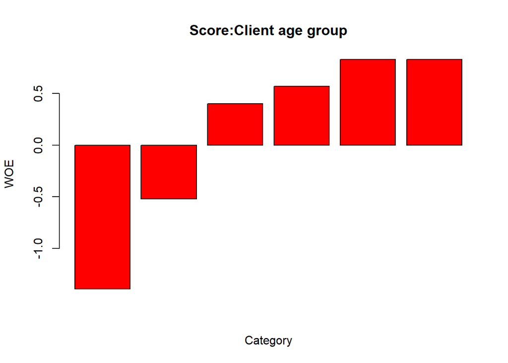

```r
WOE_Applicant_Age<-gbpct(train$Applicant_Age_grp)
barplot(WOE_Applicant_Age$WOE, col="red", names.arg=c(WOE_Applicant_Age$Levels),
        main="Score:Client age group",
        xlab="Category",
        ylab="WOE")
```

```r
kable(WOE_Applicant_Age, caption = 'Applicant Age ~ Not Default-Default')
```

Applicant Age ~ Not Default-Default

| Names | Not_Default | Default | Good_pct | Bad_pct | Total | Total_Pct | Bad_Rate | grp_score | WOE | IV | Efficiency |
| --- | --- | --- | --- | --- | --- | --- | --- | --- | --- | --- | --- |
| 0-25 | 29748 | 9485 | 16.30 | 18.74 | 39233 | 16.83 | 24.18 | 4.65 | -1.39 | 0.33916 | 1.220 |
| 25-30 | 38210 | 11162 | 20.93 | 22.05 | 49372 | 21.18 | 22.61 | 4.87 | -0.52 | 0.05824 | 0.560 |
| 30-35 | 48957 | 13036 | 26.82 | 25.76 | 61993 | 26.59 | 21.03 | 5.10 | 0.40 | 0.04240 | 0.530 |
| 35-40 | 26529 | 6951 | 14.53 | 13.73 | 33480 | 14.36 | 20.76 | 5.14 | 0.57 | 0.04560 | 0.400 |
| 40-45 | 21810 | 5565 | 11.95 | 11.00 | 27375 | 11.74 | 20.33 | 5.21 | 0.83 | 0.07885 | 0.475 |
| 45+ | 17289 | 4412 | 9.47 | 8.72 | 21701 | 9.31 | 20.33 | 5.21 | 0.83 | 0.06225 | 0.375 |

# Analysing the No of enquiries made by client WOE and IV calculation

```r
summary(train$NO.OF_INQUIRIES)
```

```
##    Min. 1st Qu.  Median    Mean 3rd Qu.    Max.
##  0.0000  0.0000  0.0000  0.2066  0.0000 36.0000
```

```r
train$No_of_enq_grp <-as.factor(ifelse(train$NO.OF_INQUIRIES<=2,'0-2',
                                       ifelse(train$NO.OF_INQUIRIES<=4,'2-4',
                                              ifelse(train$NO.OF_INQUIRIES<=6,'4-6','6+'))))
pct(train$No_of_enq_grp)
```

|  | Count | Percentage |
| --- | --- | --- |
| 0-2 | 229655 | 98.50 |
| 2-4 | 2527 | 1.08 |
| 4-6 | 582 | 0.25 |
| 6+ | 390 | 0.17 |

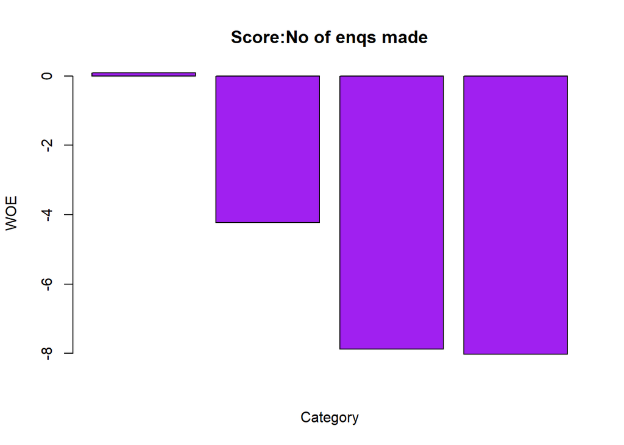

```r
WOE_No_of_enq<-gbpct(train$No_of_enq_grp)
barplot(WOE_No_of_enq$WOE, col="purple", names.arg=c(WOE_No_of_enq$Levels),
        main="Score:No of enqs made",
        xlab="Category",
        ylab="WOE")
```

```r
kable(WOE_No_of_enq, caption = 'Number of Enplquiries made ~ Not Default-Default')
```

Number of Enplquiries made ~ Not Default-Default

| Names | Not_Default | Default | Good_pct | Bad_pct | Total | Total_Pct | Bad_Rate | grp_score | WOE | IV | Efficiency |
| --- | --- | --- | --- | --- | --- | --- | --- | --- | --- | --- | --- |
| 0-2 | 180166 | 49489 | 98.70 | 97.78 | 229655 | 98.50 | 21.55 | 5.02 | 0.09 | 0.00828 | 0.460 |
| 2-4 | 1776 | 751 | 0.97 | 1.48 | 2527 | 1.08 | 29.72 | 3.96 | -4.23 | 0.21573 | 0.255 |
| 4-6 | 360 | 222 | 0.20 | 0.44 | 582 | 0.25 | 38.14 | 3.12 | -7.88 | 0.18912 | 0.120 |
| 6+ | 241 | 149 | 0.13 | 0.29 | 390 | 0.17 | 38.21 | 3.10 | -8.02 | 0.12832 | 0.080 |

# Analysing Primary Installment amount WOE and IV calculation

```r
summary(train$PRIMARY.INSTAL.AMT)
```

```
##     Min.  1st Qu.   Median     Mean  3rd Qu.     Max.
##        0        0        0    13105     1999 25642806
```

```r
train$Primary_install_grp <-as.factor(ifelse(train$PRIMARY.INSTAL.AMT<=5000,'0-5000',
                                             ifelse(train$PRIMARY.INSTAL.AMT<=25000,'5000-25000',
                                                    ifelse(train$PRIMARY.INSTAL.AMT<=50000,'25000-50000',
                                                           ifelse(train$PRIMARY.INSTAL.AMT<=75000,'50000-75000','75000+')))))

pct(train$Primary_install_grp)
```

|  | Count | Percentage |
| --- | --- | --- |
| 0-5000 | 194365 | 83.36 |
| 25000-50000 | 4820 | 2.07 |
| 5000-25000 | 26605 | 11.41 |
| 50000-75000 | 1519 | 0.65 |
| 75000+ | 5845 | 2.51 |

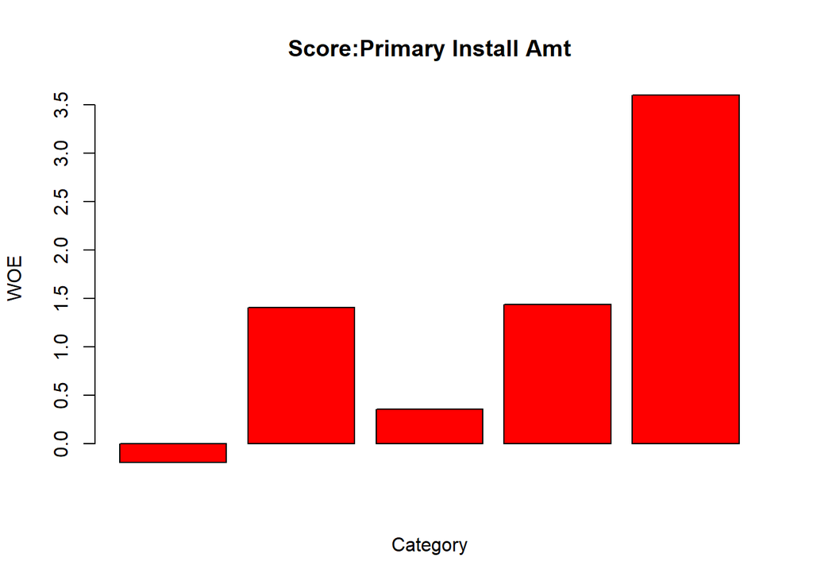

```r
WOE_primary_install<-gbpct(train$Primary_install_grp)
barplot(WOE_primary_install$WOE, col="red", names.arg=c(WOE_primary_install$Levels),
        main="Score:Primary Install Amt",
        xlab="Category",
        ylab="WOE")
```

```r
kable(WOE_primary_install, caption = 'Primary Intallment Amount ~ Not Default-Default')
```

Primary Intallment Amount ~ Not Default-Default

| Names | Not_Default | Default | Good_pct | Bad_pct | Total | Total_Pct | Bad_Rate | grp_score | WOE | IV | Efficiency |
| --- | --- | --- | --- | --- | --- | --- | --- | --- | --- | --- | --- |
| 0-5000 | 151547 | 42818 | 83.02 | 84.60 | 194365 | 83.36 | 22.03 | 4.95 | -0.19 | 0.03002 | 0.790 |
| 25000-50000 | 3883 | 937 | 2.13 | 1.85 | 4820 | 2.07 | 19.44 | 5.35 | 1.41 | 0.03948 | 0.140 |
| 5000-25000 | 20991 | 5614 | 11.50 | 11.09 | 26605 | 11.41 | 21.10 | 5.09 | 0.36 | 0.01476 | 0.205 |
| 50000-75000 | 1224 | 295 | 0.67 | 0.58 | 1519 | 0.65 | 19.42 | 5.36 | 1.44 | 0.01296 | 0.045 |
| 75000+ | 4898 | 947 | 2.68 | 1.87 | 5845 | 2.51 | 16.20 | 5.89 | 3.60 | 0.29160 | 0.405 |

# Secondary account installment WOE

```r
summary(train$SEC.INSTAL.AMT)
```

```
##    Min. 1st Qu.  Median    Mean 3rd Qu.    Max.
##       0       0       0     323       0 4170901
```

```r
train$Secondary_install_grp <-as.factor(ifelse(train$SEC.INSTAL.AMT<=5000,'0-5000',
                                               ifelse(train$SEC.INSTAL.AMT<=25000,'5000-25000',
                                                      ifelse(train$SEC.INSTAL.AMT<=50000,'25000-50000',
                                                             ifelse(train$SEC.INSTAL.AMT<=75000,'50000-75000','75000+')))))

pct(train$Secondary_install_grp)
```

|  | Count | Percentage |
| --- | --- | --- |
| 0-5000 | 232102 | 99.55 |
| 25000-50000 | 117 | 0.05 |
| 5000-25000 | 700 | 0.30 |
| 50000-75000 | 43 | 0.02 |
| 75000+ | 192 | 0.08 |

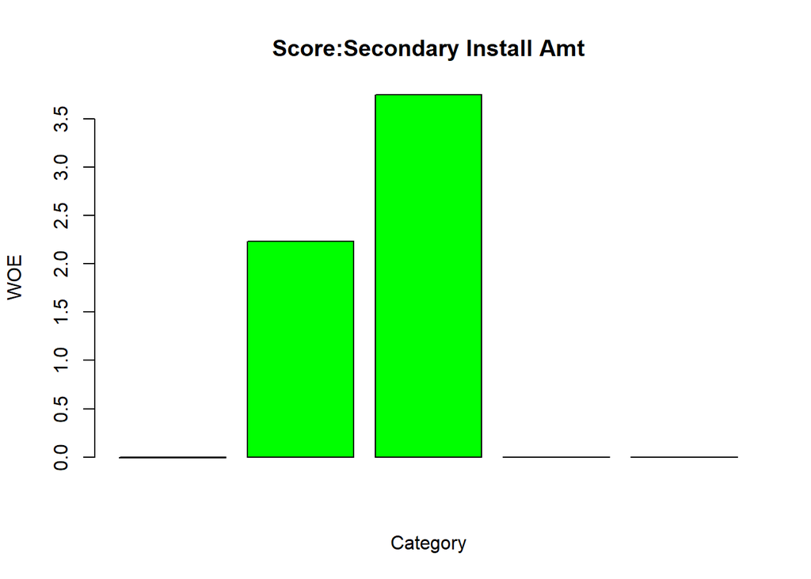

```r
WOE_secondary_install<-gbpct(train$Secondary_install_grp)
barplot(WOE_secondary_install$WOE, col="green", names.arg=c(WOE_secondary_install$Levels),
        main="Score:Secondary Install Amt",
        xlab="Category",
        ylab="WOE")
```

```r
kable(WOE_secondary_install, caption = 'Secondary Installment Amount ~ Not Default-Default')
```

Secondary Installment Amount ~ Not Default-Default

| Names | Not_Default | Default | Good_pct | Bad_pct | Total | Total_Pct | Bad_Rate | grp_score | WOE | IV | Efficiency |
| --- | --- | --- | --- | --- | --- | --- | --- | --- | --- | --- | --- |
| 0-5000 | 181670 | 50432 | 99.52 | 99.65 | 232102 | 99.55 | 21.73 | 5.00 | -0.01 | 0.00013 | 0.065 |
| 25000-50000 | 97 | 20 | 0.05 | 0.04 | 117 | 0.05 | 17.09 | 5.56 | 2.23 | 0.00223 | 0.005 |
| 5000-25000 | 590 | 110 | 0.32 | 0.22 | 700 | 0.30 | 15.71 | 5.93 | 3.75 | 0.03750 | 0.050 |
| 50000-75000 | 34 | 9 | 0.02 | 0.02 | 43 | 0.02 | 20.93 | 5.00 | 0.00 | 0.00000 | 0.000 |
| 75000+ | 152 | 40 | 0.08 | 0.08 | 192 | 0.08 | 20.83 | 5.00 | 0.00 | 0.00000 | 0.000 |

# Analysing the Primary number of active accounts at the time of loan applicaton WOE & IV calculation

```r
summary(train$PRI.ACTIVE.ACCTS)
```

```
##    Min. 1st Qu.  Median    Mean 3rd Qu.    Max.
##    0.00    0.00    0.00    1.04    1.00  144.00
```

```r
train$Pri_active__acc_grp <-as.factor(ifelse(train$PRI.ACTIVE.ACCTS<=5,'0-5',
                                             ifelse(train$PRI.ACTIVE.ACCTS<=10,'5-10',
                                                    ifelse(train$PRI.ACTIVE.ACCTS<=15,'10-15','15+'))))
pct(train$Pri_active__acc_grp)
```

|  | Count | Percentage |
| --- | --- | --- |
| 0-5 | 224890 | 96.46 |
| 10-15 | 952 | 0.41 |
| 15+ | 256 | 0.11 |
| 5-10 | 7056 | 3.03 |

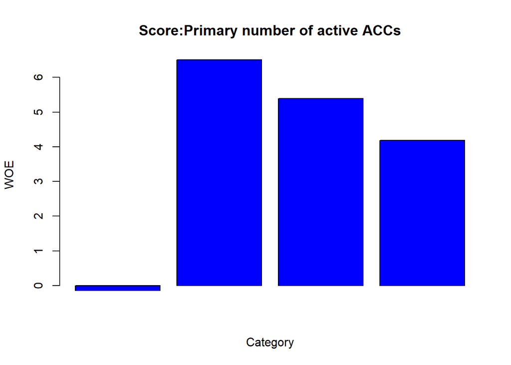

```r
WOE_Pri_active__acc<-gbpct(train$Pri_active__acc_grp)
barplot(WOE_Pri_active__acc$WOE, col="blue", names.arg=c(WOE_Pri_active__acc$Levels),
        main="Score:Primary number of active ACCs",
        xlab="Category",
        ylab="WOE")
```

```r
kable(WOE_Pri_active__acc,caption = 'number of active Primary Accounts ~ Not Default-Default')
```

number of active Primary Accounts ~ Not Default-Default

| Names | Not_Default | Default | Good_pct | Bad_pct | Total | Total_Pct | Bad_Rate | grp_score | WOE | IV | Efficiency |
| --- | --- | --- | --- | --- | --- | --- | --- | --- | --- | --- | --- |
| 0-5 | 175521 | 49369 | 96.15 | 97.55 | 224890 | 96.46 | 21.95 | 4.96 | -0.14 | 0.01960 | 0.700 |
| 10-15 | 831 | 121 | 0.46 | 0.24 | 952 | 0.41 | 12.71 | 6.57 | 6.51 | 0.14322 | 0.110 |
| 15+ | 221 | 35 | 0.12 | 0.07 | 256 | 0.11 | 13.67 | 6.32 | 5.39 | 0.02695 | 0.025 |
| 5-10 | 5970 | 1086 | 3.27 | 2.15 | 7056 | 3.03 | 15.39 | 6.03 | 4.19 | 0.46928 | 0.560 |

# Analysing the Secondary number of active accounts at the time of loan applicaton WOE & IV calculation

```r
summary(train$SEC.ACTIVE.ACCTS)
```

```
##    Min. 1st Qu.  Median    Mean 3rd Qu.    Max.
##  0.0000  0.0000  0.0000  0.0277  0.0000 36.0000
```

```r
train$sec_active__acc_grp <-as.factor(ifelse(train$SEC.ACTIVE.ACCTS<=5,'0-5',
                                             ifelse(train$SEC.ACTIVE.ACCTS<=10,'5-10','10+')))
pct(train$sec_active__acc_grp)
```

|  | Count | Percentage |
| --- | --- | --- |
| 0-5 | 233033 | 99.95 |
| 10+ | 30 | 0.01 |
| 5-10 | 91 | 0.04 |

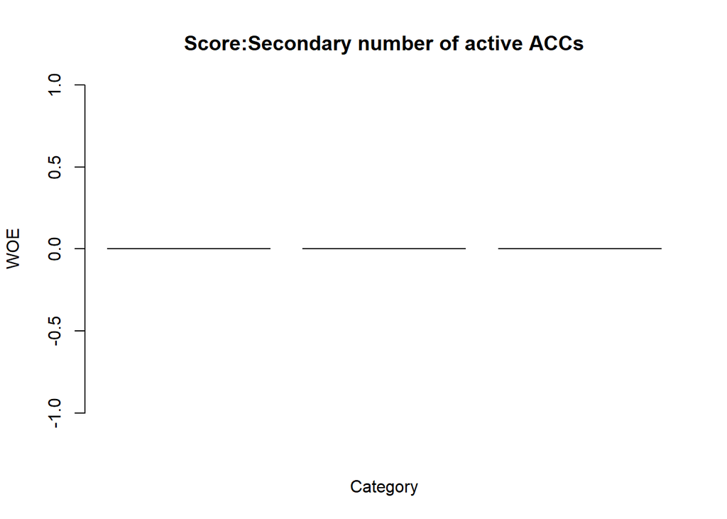

```r
WOE_sec_active__acc<-gbpct(train$sec_active__acc_grp)
barplot(WOE_sec_active__acc$WOE, col="brown", names.arg=c(WOE_sec_active__acc$Levels),
        main="Score:Secondary number of active ACCs",
        xlab="Category",
        ylab="WOE")
```

```r
kable(WOE_sec_active__acc,caption = 'number of secondary actie accounts ~ Not Default-Default')
```

number of secondary actie accounts ~ Not Default-Default

| Names | Not_Default | Default | Good_pct | Bad_pct | Total | Total_Pct | Bad_Rate | grp_score | WOE | IV | Efficiency |
| --- | --- | --- | --- | --- | --- | --- | --- | --- | --- | --- | --- |
| 0-5 | 182445 | 50588 | 99.95 | 99.95 | 233033 | 99.95 | 21.71 | 5 | 0 | 0 | 0 |
| 10+ | 25 | 5 | 0.01 | 0.01 | 30 | 0.01 | 16.67 | 5 | 0 | 0 | 0 |
| 5-10 | 73 | 18 | 0.04 | 0.04 | 91 | 0.04 | 19.78 | 5 | 0 | 0 | 0 |

# Analysing the primary overdue accounts;WOE and IV calculation

```r
summary(train$PRI.OVERDUE.ACCTS)
```

```
##    Min. 1st Qu.  Median    Mean 3rd Qu.    Max.
##  0.0000  0.0000  0.0000  0.1565  0.0000 25.0000
```

```r
train$Pri_overdue__acc_grp <-as.factor(ifelse(train$PRI.OVERDUE.ACCTS<=5,'0-5',
                                              ifelse(train$PRI.OVERDUE.ACCTS<=10,'5-10','10+')))
pct(train$Pri_overdue__acc_grp)
```

|  | Count | Percentage |
| --- | --- | --- |
| 0-5 | 232923 | 99.90 |
| 10+ | 39 | 0.02 |
| 5-10 | 192 | 0.08 |

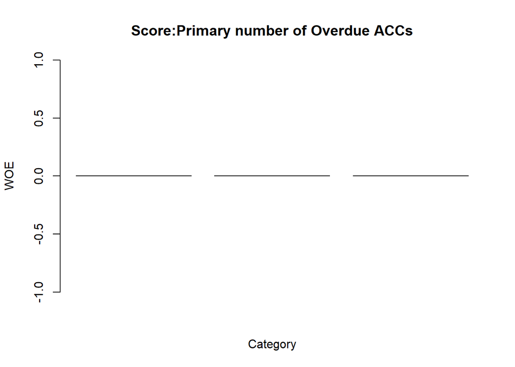

```r
WOE_Pri_overdue__acc<-gbpct(train$Pri_overdue__acc_grp)
barplot(WOE_Pri_overdue__acc$WOE, col="green", names.arg=c(WOE_Pri_overdue__acc$Levels),
        main="Score:Primary number of Overdue ACCs",
        xlab="Category",
        ylab="WOE")
```

```r
kable(WOE_Pri_overdue__acc,caption = 'number of Primary overdue accounts ~ Not Default-Default')
```

number of Primary overdue accounts ~ Not Default-Default

| Names | Not_Default | Default | Good_pct | Bad_pct | Total | Total_Pct | Bad_Rate | grp_score | WOE | IV | Efficiency |
| --- | --- | --- | --- | --- | --- | --- | --- | --- | --- | --- | --- |
| 0-5 | 182363 | 50560 | 99.90 | 99.90 | 232923 | 99.90 | 21.71 | 5 | 0 | 0 | 0 |
| 10+ | 29 | 10 | 0.02 | 0.02 | 39 | 0.02 | 25.64 | 5 | 0 | 0 | 0 |
| 5-10 | 151 | 41 | 0.08 | 0.08 | 192 | 0.08 | 21.35 | 5 | 0 | 0 | 0 |

# Analysing the secondary overdue accounts;WOE and IV calculation

```r
summary(train$SEC.OVERDUE.ACCTS)
```

```
##     Min.  1st Qu.   Median     Mean  3rd Qu.     Max.
## 0.000000 0.000000 0.000000 0.007244 0.000000 8.000000
```

```r
train$sec_overdue__acc_grp <-as.factor(ifelse(train$SEC.OVERDUE.ACCTS<=2,'0-2',
                                              ifelse(train$SEC.OVERDUE.ACCTS<=4,'2-4','4+')))
pct(train$sec_overdue__acc_grp)
```

|  | Count | Percentage |
| --- | --- | --- |
| 0-2 | 233072 | 99.96 |
| 2-4 | 66 | 0.03 |
| 4+ | 16 | 0.01 |

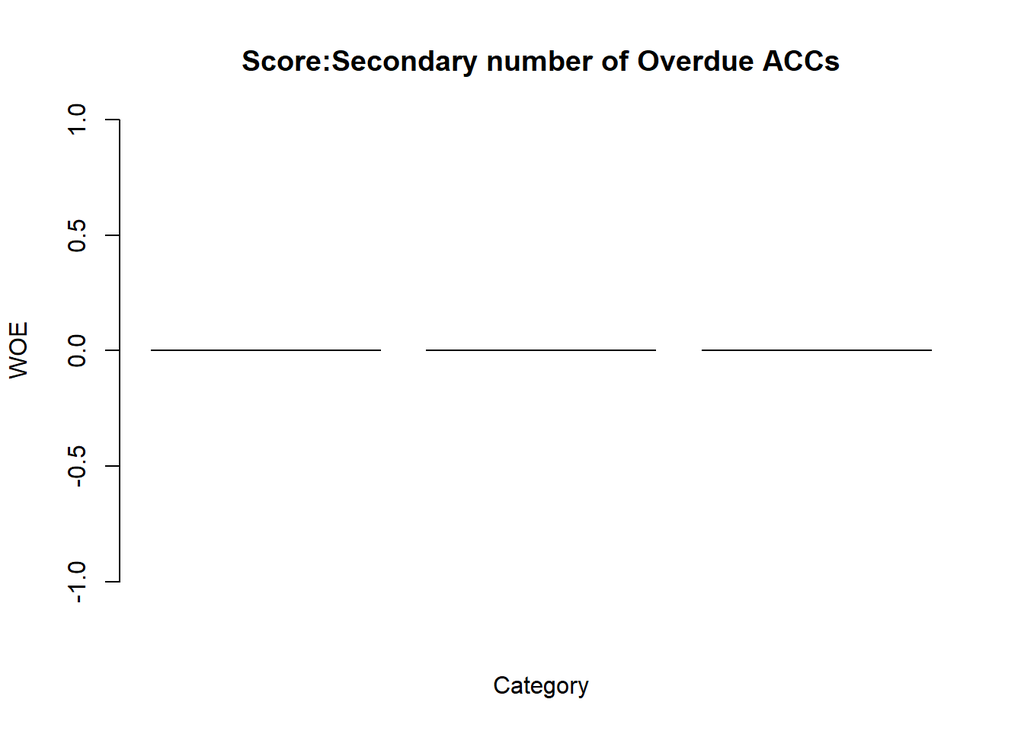

```r
WOE_sec_overdue__acc<-gbpct(train$sec_overdue__acc_grp)
barplot(WOE_sec_overdue__acc$WOE, col="green", names.arg=c(WOE_sec_overdue__acc$Levels),
        main="Score:Secondary number of Overdue ACCs",
        xlab="Category",
        ylab="WOE")
```

```r
kable(WOE_sec_overdue__acc,caption = 'number of Secondary overdue accounts ~ Not Default-Default')
```

number of Secondary overdue accounts ~ Not Default-Default

| Names | Not_Default | Default | Good_pct | Bad_pct | Total | Total_Pct | Bad_Rate | grp_score | WOE | IV | Efficiency |
| --- | --- | --- | --- | --- | --- | --- | --- | --- | --- | --- | --- |
| 0-2 | 182479 | 50593 | 99.96 | 99.96 | 233072 | 99.96 | 21.71 | 5 | 0 | 0 | 0 |
| 2-4 | 52 | 14 | 0.03 | 0.03 | 66 | 0.03 | 21.21 | 5 | 0 | 0 | 0 |
| 4+ | 12 | 4 | 0.01 | 0.01 | 16 | 0.01 | 25.00 | 5 | 0 | 0 | 0 |

# Analysing Primary outstanding balance WOE (total principal outstanding);WOE and IV calculation

```r
summary(train$PRI.CURRENT.BALANCE)
```

```
##     Min.  1st Qu.   Median     Mean  3rd Qu.     Max.
## -6678296        0        0   165900    35006 96524920
```

```r
median(train$PRI.CURRENT.BALANCE)   #0
```

```
## [1] 0
```

```r
#I found out that for a few customers the outstanding amount has negative values in it
#So asuuming those values are wrong entries , replaced those vales with the median valeues.
train$PRI.CURRENT.BALANCE<-ifelse(train$PRI.CURRENT.BALANCE < 0 ,0,as.numeric(train$PRI.CURRENT.BALANCE))
train$pri_outstand_grp <-as.factor(ifelse(train$PRI.CURRENT.BALANCE<=15000,'0-15000',
                                          ifelse(train$PRI.CURRENT.BALANCE<=25000,'15000-25000',
                                                 ifelse(train$PRI.CURRENT.BALANCE<=50000,'25000-50000',
                                                        ifelse(train$PRI.CURRENT.BALANCE<=100000,'50000-100000','100000+')))))

pct(train$pri_outstand_grp)
```

|  | Count | Percentage |
| --- | --- | --- |
| 0-15000 | 161868 | 69.43 |
| 100000+ | 38745 | 16.62 |
| 15000-25000 | 7433 | 3.19 |
| 25000-50000 | 12584 | 5.40 |
| 50000-100000 | 12524 | 5.37 |

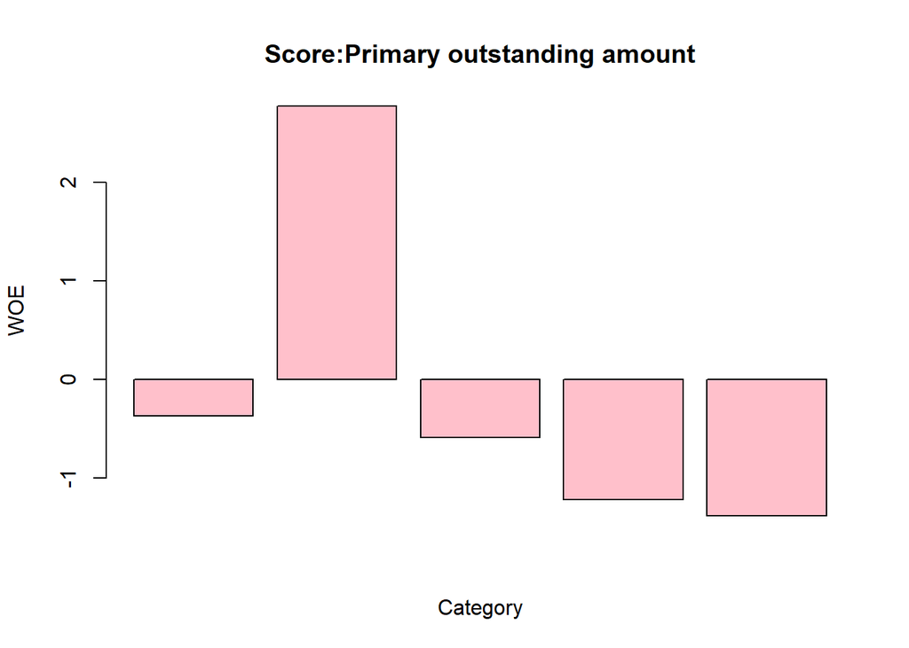

```r
WOE_pri_outstand_grp<-gbpct(train$pri_outstand_grp)
barplot(WOE_pri_outstand_grp$WOE, col="pink", names.arg=c(WOE_pri_outstand_grp$Levels),
        main="Score:Primary outstanding amount",
        xlab="Category",
        ylab="WOE")
```

```r
kable(WOE_pri_outstand_grp,caption = 'Primary outstanding amount ~ Not Default-Default')
```

Primary outstanding amount ~ Not Default-Default

| Names | Not_Default | Default | Good_pct | Bad_pct | Total | Total_Pct | Bad_Rate | grp_score | WOE | IV | Efficiency |
| --- | --- | --- | --- | --- | --- | --- | --- | --- | --- | --- | --- |
| 0-15000 | 125696 | 36172 | 68.86 | 71.47 | 161868 | 69.43 | 22.35 | 4.91 | -0.37 | 0.09657 | 1.305 |
| 100000+ | 32021 | 6724 | 17.54 | 13.29 | 38745 | 16.62 | 17.35 | 5.69 | 2.77 | 1.17725 | 2.125 |
| 15000-25000 | 5743 | 1690 | 3.15 | 3.34 | 7433 | 3.19 | 22.74 | 4.85 | -0.59 | 0.01121 | 0.095 |
| 25000-50000 | 9583 | 3001 | 5.25 | 5.93 | 12584 | 5.40 | 23.85 | 4.70 | -1.22 | 0.08296 | 0.340 |
| 50000-100000 | 9500 | 3024 | 5.20 | 5.97 | 12524 | 5.37 | 24.15 | 4.66 | -1.38 | 0.10626 | 0.385 |

# Secondary outstanding balance WOE (total principal outstanding)

```r
summary(train$SEC.CURRENT.BALANCE)
```

```
##     Min.  1st Qu.   Median     Mean  3rd Qu.     Max.
##  -574647        0        0     5428        0 36032852
```

```r
median(train$SEC.CURRENT.BALANCE)   #0
```

```
## [1] 0
```

```r
#Wrong entries are replaced with median values

train$SEC.CURRENT.BALANCE<-ifelse(train$SEC.CURRENT.BALANCE < 0 ,0,as.numeric(train$SEC.CURRENT.BALANCE))
train$sec_outstand_grp <-as.factor(ifelse(train$SEC.CURRENT.BALANCE<=5000,'0-5000',
                                          ifelse(train$SEC.CURRENT.BALANCE<=10000,'5000-10000',
                                                 ifelse(train$SEC.CURRENT.BALANCE<=15000,'10000-15000',
                                                        ifelse(train$SEC.CURRENT.BALANCE<=30000,'15000-30000','30000+')))))

pct(train$sec_outstand_grp)
```

|  | Count | Percentage |
| --- | --- | --- |
| 0-5000 | 230266 | 98.76 |
| 10000-15000 | 164 | 0.07 |
| 15000-30000 | 378 | 0.16 |
| 30000+ | 2087 | 0.90 |
| 5000-10000 | 259 | 0.11 |

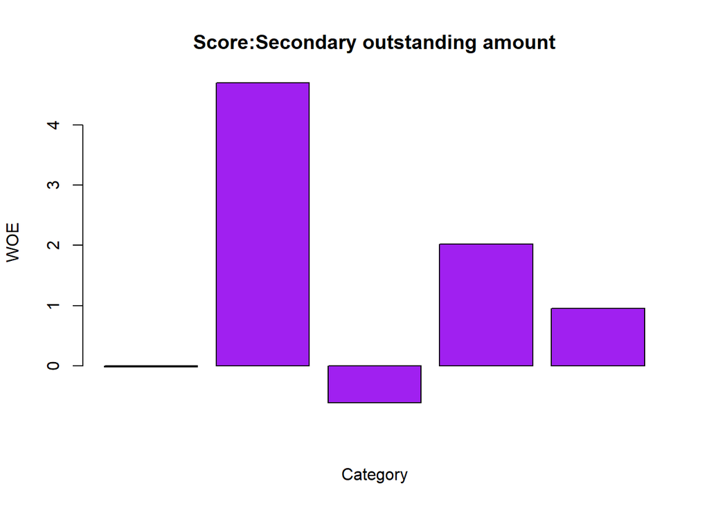

```r
WOE_sec_outstand_grp<-gbpct(train$sec_outstand_grp)
barplot(WOE_sec_outstand_grp$WOE, col="purple", names.arg=c(WOE_sec_outstand_grp$Levels),
        main="Score:Secondary outstanding amount",
        xlab="Category",
        ylab="WOE")
```

```r
kable(WOE_sec_outstand_grp,caption = 'Secondary outstanding amount ~ Not Default-Default')
```

Secondary outstanding amount ~ Not Default-Default

| Names | Not_Default | Default | Good_pct | Bad_pct | Total | Total_Pct | Bad_Rate | grp_score | WOE | IV | Efficiency |
| --- | --- | --- | --- | --- | --- | --- | --- | --- | --- | --- | --- |
| 0-5000 | 180206 | 50060 | 98.72 | 98.91 | 230266 | 98.76 | 21.74 | 5.00 | -0.02 | 0.00038 | 0.095 |
| 10000-15000 | 139 | 25 | 0.08 | 0.05 | 164 | 0.07 | 15.24 | 6.15 | 4.70 | 0.01410 | 0.015 |
| 15000-30000 | 290 | 88 | 0.16 | 0.17 | 378 | 0.16 | 23.28 | 4.85 | -0.61 | 0.00061 | 0.005 |
| 30000+ | 1702 | 385 | 0.93 | 0.76 | 2087 | 0.90 | 18.45 | 5.50 | 2.02 | 0.03434 | 0.085 |
| 5000-10000 | 206 | 53 | 0.11 | 0.10 | 259 | 0.11 | 20.46 | 5.24 | 0.95 | 0.00095 | 0.005 |